# Energy

# 1 Description of DataSchema variable

The description of harmonised variable is the following:

- Short name: `energy`
- Variable label: `Self-reported level of energy`
- Variable description: `Self-reported high level of energy experienced at the time of the interview. Dichotomous variable: 0 refers to lack of energy or presence of fatigue/being listless, and 1 refers to energy in a high level or most of the time`
- Domain: `Health status and functional limitations`
- Value type: `categorical`
- Category coding:

| **Code** | **Category Label** |
| --- | --- |
| 0 | Lack of energy |
| 1 | High level of energy |

- Category missings:

| **Code** | **Category Label** |
| --- | --- |
| 991 | CAPI/interviewer error |
| 992 | Impute |
| 993 | Disable to measure |
| 994 | Not attempt/not done |
| 995 | Does not answer |
| 996 | Not applicable |
| 997 | Refuse |
| 998 | Do not know |
| 999 | Missing |

# 2 Data process

## 2.1 England

### 2.1.1 Wave 1

#### 2.1.1.1 Study-specific variable description

| **Name** | `scqolo` |
| --- | --- |
| **Label** | `How often feels full of energy these days` |
| **Table name** | `wave_1_core_data_v3` |
| **Categories** | `1 = Often; 2 = Sometimes; 3 = Not often; 4 = Never` |
| **Missings** | `-9 = Not answered; -1 = Item not applicable` |
| **Description** |  |

scqolo

| Sample size | Missing values |
| --- | --- |
| 12099 | 1321 |

Category

|  | 1 | 2 | 3 | 4 |
| --- | --- | --- | --- | --- |
| Frequency | 2793.00 | 5339.00 | 1951.00 | 695.00 |
| Percentage | 23.08 | 44.13 | 16.13 | 5.74 |

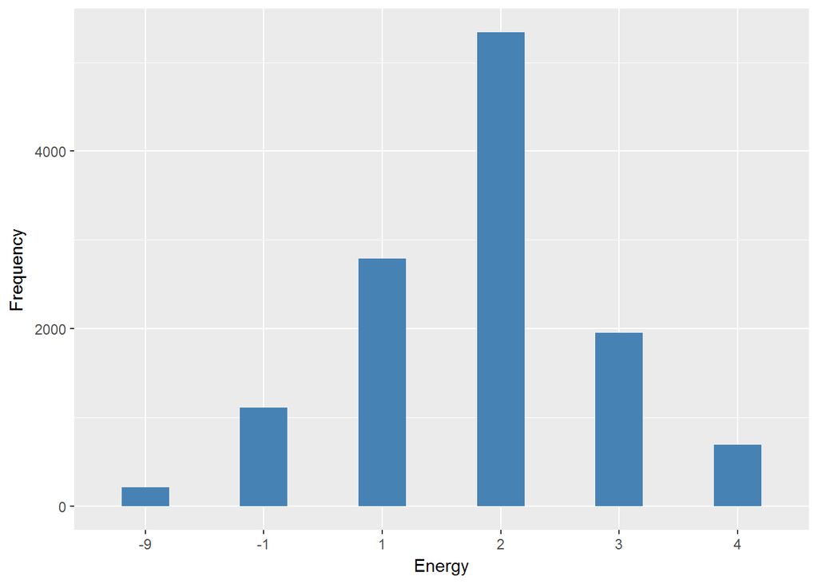

#### 2.1.1.2 Harmonisation algorithm

To compute the harmonize variable from the study-specific variable it has to be recoded as follows:

- `1 into 1`
- `2 into 0`
- `3 into 0`
- `4 into 0`
- `-9 Not answered into 995`
- `-1 Item not applicable into 996`

**R script:**

```r
ELSA_ds_w1 <- tibble(id = ELSA_w1_energy$id)
ELSA_ds_w1$energy <- car::recode(ELSA_w1_energy$scqolo, "1 = '1';2 = '0';3 = '0';4 = '0';-9 = '995';-1 = '996' ")
ELSA_ds_w1$energy <- labelled(ELSA_ds_w1$energy, labels = c(Yes = 0, No = 1,
    Missing = 999, Do_not_know = 998, Refuse = 997, Not_applicable = 996, Does_not_answer = 995,
    Not_attempt_not_done = 994, Disable_to_measure = 993, Impute = 992, CAPI_interviewer_error = 991,
    Do_not_know = 998))
```

#### 2.1.1.3 Statistical description of the new harmonised variable

energy

| Sample size | Missing values |
| --- | --- |
| 12099 | 1321 |

Category

|  | 0 | 1 |
| --- | --- | --- |
| Frequency | 7985 | 2793.00 |
| Percentage | 66 | 23.08 |

Type of missing

|  | 991 | 992 | 993 | 994 | 995 | 996 | 997 | 998 | 999 | NA |
| --- | --- | --- | --- | --- | --- | --- | --- | --- | --- | --- |
| Frequency | 0 | 0 | 0 | 0 | 213.00 | 1108.00 | 0 | 0 | 0 | 0 |
| Percentage | 0 | 0 | 0 | 0 | 1.76 | 9.16 | 0 | 0 | 0 | 0 |

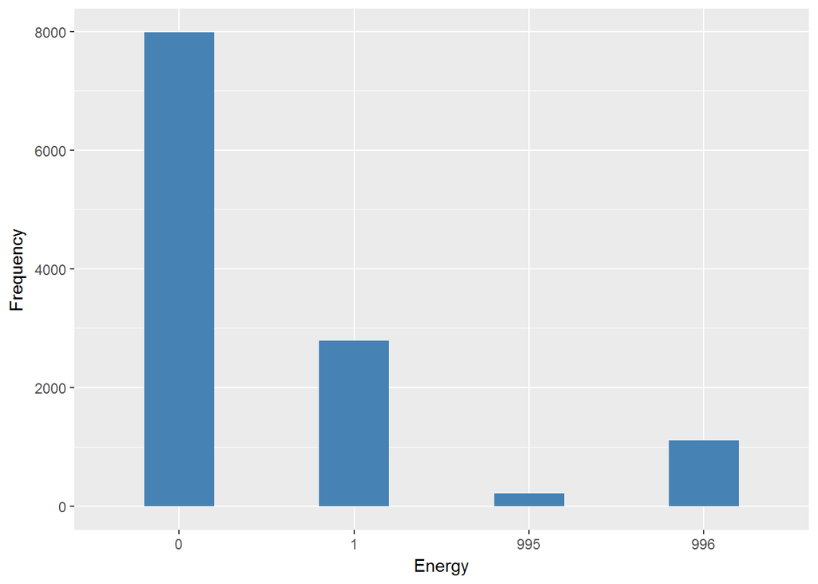

#### 2.1.1.4 Validation

|  | 1->1 | 2,3,4->0 | -9->995 | -1->996 |
| --- | --- | --- | --- | --- |
| BeforeH | 7985 | 2793 | 213 | 1108 |
| AfterH | 7985 | 2793 | 213 | 1108 |

### 2.1.2 Wave 2

#### 2.1.2.1 Study-specific variable description

| **Name** | `scqolo` |
| --- | --- |
| **Label** | `How often feels full of energy these days` |
| **Table name** | `wave_2_core_data_v4` |
| **Categories** | `1 = Often; 2 = Sometimes; 3 = Not often; 4 = Never` |
| **Missings** | `-9 = Not answered; -1 = Item not applicable` |
| **Description** |  |

scqolo

| Sample size | Missing values |
| --- | --- |
| 9432 | 1269 |

Category

|  | 1 | 2 | 3 | 4 |
| --- | --- | --- | --- | --- |
| Frequency | 2093.00 | 3995.00 | 1552.00 | 523.00 |
| Percentage | 22.19 | 42.36 | 16.45 | 5.54 |

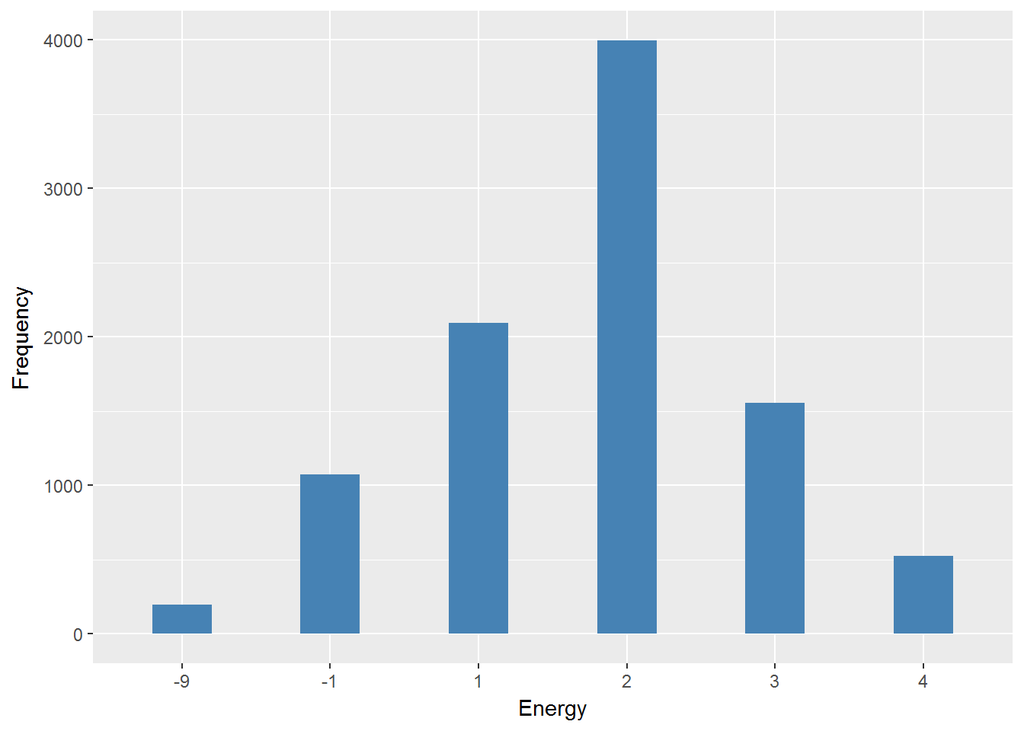

#### 2.1.2.2 Harmonisation algorithm

To compute the harmonize variable from the study-specific variable it has to be recoded as follows:

- `1 into 1`
- `2 into 0`
- `3 into 0`
- `4 into 0`
- `-9 Not answered into 995`
- `-1 Item not applicable into 996`

**R script:**

```r
ELSA_ds_w2 <- tibble(id = ELSA_w2_energy$id)
ELSA_ds_w2$energy <- car::recode(ELSA_w2_energy$scqolo, "1 = '1';2 = '0';3 = '0';4 = '0';-9 = '995';-1 = '996' ")
ELSA_ds_w2$energy <- labelled(ELSA_ds_w2$energy, labels = c(Yes = 0, No = 1,
    Missing = 999, Do_not_know = 998, Refuse = 997, Not_applicable = 996, Does_not_answer = 995,
    Not_attempt_not_done = 994, Disable_to_measure = 993, Impute = 992, CAPI_interviewer_error = 991,
    Do_not_know = 998))
```

#### 2.1.2.3 Statistical description of the new harmonised variable

energy

| Sample size | Missing values |
| --- | --- |
| 9432 | 1269 |

Category

|  | 0 | 1 |
| --- | --- | --- |
| Frequency | 6070.00 | 2093.00 |
| Percentage | 64.36 | 22.19 |

Type of missing

|  | 991 | 992 | 993 | 994 | 995 | 996 | 997 | 998 | 999 | NA |
| --- | --- | --- | --- | --- | --- | --- | --- | --- | --- | --- |
| Frequency | 0 | 0 | 0 | 0 | 197.00 | 1072.00 | 0 | 0 | 0 | 0 |
| Percentage | 0 | 0 | 0 | 0 | 2.09 | 11.37 | 0 | 0 | 0 | 0 |

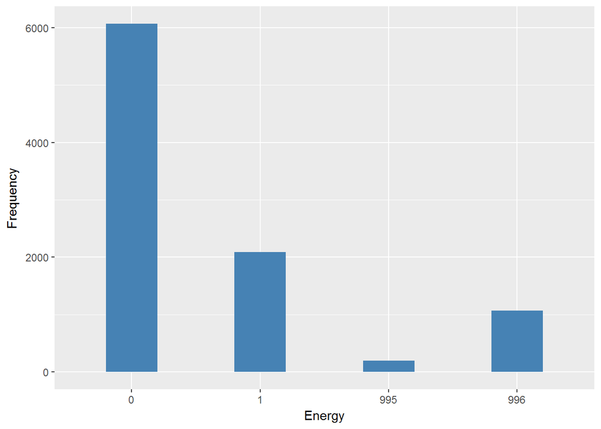

#### 2.1.2.4 Validation

|  | 1->1 | 2,3,4->0 | -9->995 | -1->996 |
| --- | --- | --- | --- | --- |
| BeforeH | 6070 | 2093 | 197 | 1072 |
| AfterH | 6070 | 2093 | 197 | 1072 |

### 2.1.3 Wave 3

#### 2.1.3.1 Study-specific variable description

| **Name** | `scqolo` |
| --- | --- |
| **Label** | `How often feels full of energy these days` |
| **Table name** | `wave_3_elsa_data_v4` |
| **Categories** | `1 = Often; 2 = Sometimes; 3 = Not often; 4 = Never` |
| **Missings** | `-9 = Not answered; -8 = Don't know; -1 = Item not applicable` |
| **Description** |  |

scqolo

| Sample size | Missing values |
| --- | --- |
| 9771 | 1650 |

Category

|  | 1 | 2 | 3 | 4 |
| --- | --- | --- | --- | --- |
| Frequency | 1604.00 | 4216.00 | 1716.00 | 585.00 |
| Percentage | 16.42 | 43.15 | 17.56 | 5.99 |

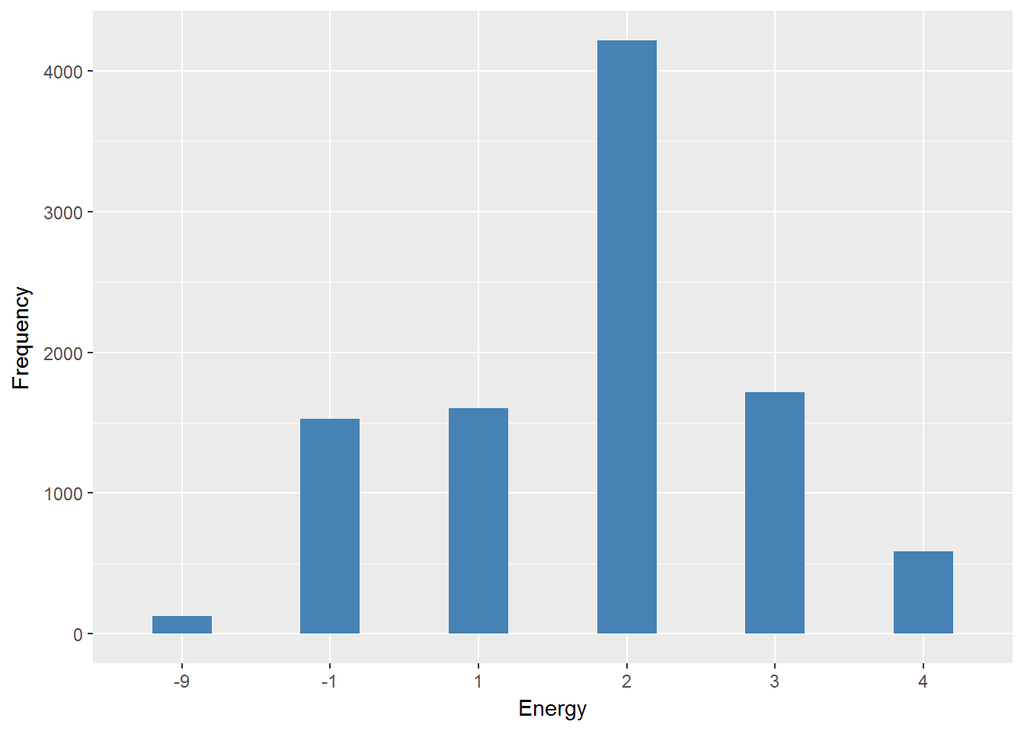

#### 2.1.3.2 Harmonisation algorithm

To compute the harmonize variable from the study-specific variable it has to be recoded as follows:

- `1 into 1`
- `2 into 0`
- `3 into 0`
- `4 into 0`
- `-9 Not answered into 995`
- `-1 Item not applicable into 996`

**R script:**

```r
ELSA_ds_w3 <- tibble(id = ELSA_w3_energy$id)
ELSA_ds_w3$energy <- car::recode(ELSA_w3_energy$scqolo, "1 = '1';2 = '0';3 = '0';4 = '0';-9 = '995';-1 = '996' ")
ELSA_ds_w3$energy <- labelled(ELSA_ds_w3$energy, labels = c(Yes = 0, No = 1,
    Missing = 999, Do_not_know = 998, Refuse = 997, Not_applicable = 996, Does_not_answer = 995,
    Not_attempt_not_done = 994, Disable_to_measure = 993, Impute = 992, CAPI_interviewer_error = 991))
```

#### 2.1.3.3 Statistical description of the new harmonised variable

energy

| Sample size | Missing values |
| --- | --- |
| 9771 | 1650 |

Category

|  | 0 | 1 |
| --- | --- | --- |
| Frequency | 6517.0 | 1604.00 |
| Percentage | 66.7 | 16.42 |

Type of missing

|  | 991 | 992 | 993 | 994 | 995 | 996 | 997 | 998 | 999 | NA |
| --- | --- | --- | --- | --- | --- | --- | --- | --- | --- | --- |
| Frequency | 0 | 0 | 0 | 0 | 123.00 | 1527.00 | 0 | 0 | 0 | 0 |
| Percentage | 0 | 0 | 0 | 0 | 1.26 | 15.63 | 0 | 0 | 0 | 0 |

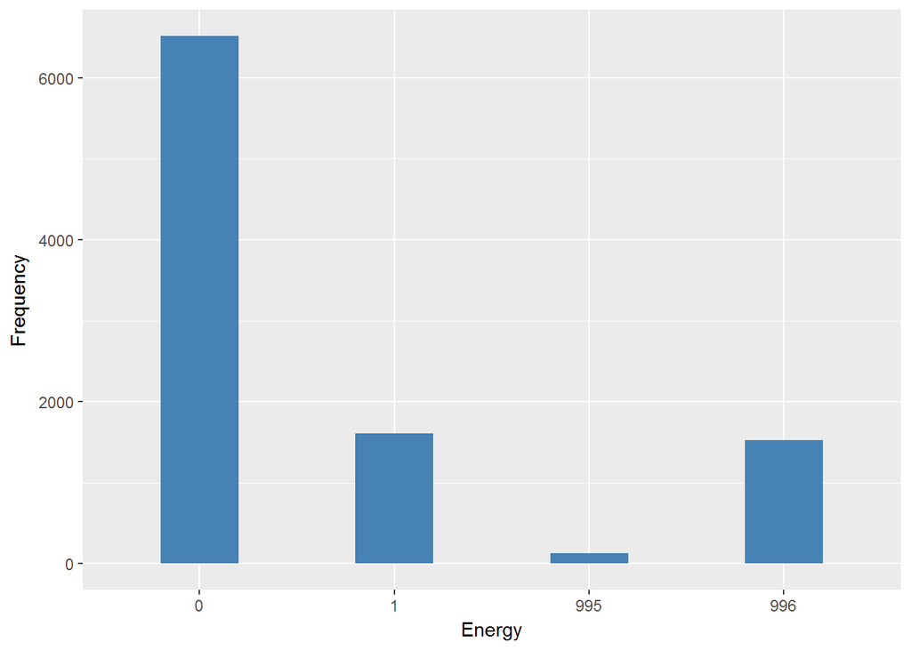

#### 2.1.3.4 Validation

|  | 1->1 | 2,3,4->0 | -9->995 | -1->996 |
| --- | --- | --- | --- | --- |
| BeforeH | 6517 | 1604 | 123 | 1527 |
| AfterH | 6517 | 1604 | 123 | 1527 |

### 2.1.4 Wave 4

#### 2.1.4.1 Study-specific variable description

| **Name** | `scqolo` |
| --- | --- |
| **Label** | `How often feels full of energy these days` |
| **Table name** | `wave_4_elsa_data_v3` |
| **Categories** | `1 = Often; 2 = Sometimes; 3 = Not often; 4 = Never` |
| **Missings** | `-9 = Not answered; -8 = Don't know; -1 = Item not applicable` |
| **Description** |  |

scqolo

| Sample size | Missing values |
| --- | --- |
| 11050 | 1864 |

Category

|  | 1 | 2 | 3 | 4 |
| --- | --- | --- | --- | --- |
| Frequency | 1957.00 | 4660.00 | 1931.00 | 638.00 |
| Percentage | 17.71 | 42.17 | 17.48 | 5.77 |

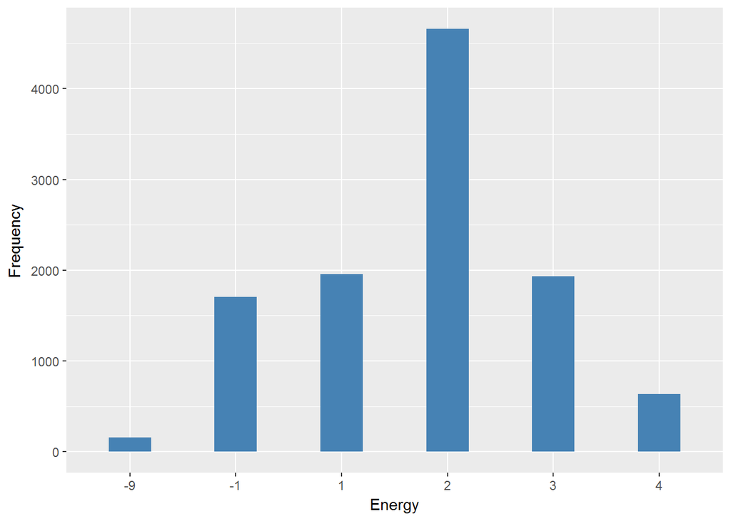

#### 2.1.4.2 Harmonisation algorithm

To compute the harmonize variable from the study-specific variable it has to be recoded as follows:

- `1 into 1`
- `2 into 0`
- `3 into 0`
- `4 into 0`
- `-9 Not answered into 995`
- `-1 Item not applicable into 996`

**R script:**

```r
ELSA_ds_w4 <- tibble(id = ELSA_w4_energy$id)
ELSA_ds_w4$energy <- car::recode(ELSA_w4_energy$scqolo, "1 = '1';2 = '0';3 = '0';4 = '0';-9 = '995';-1 = '996' ")
ELSA_ds_w4$energy <- labelled(ELSA_ds_w4$energy, labels = c(Yes = 0, No = 1,
    Missing = 999, Do_not_know = 998, Refuse = 997, Not_applicable = 996, Does_not_answer = 995,
    Not_attempt_not_done = 994, Disable_to_measure = 993, Impute = 992, CAPI_interviewer_error = 991))
```

#### 2.1.4.3 Statistical description of the new harmonised variable

energy

| Sample size | Missing values |
| --- | --- |
| 11050 | 1864 |

Category

|  | 0 | 1 |
| --- | --- | --- |
| Frequency | 7229.00 | 1957.00 |
| Percentage | 65.42 | 17.71 |

Type of missing

|  | 991 | 992 | 993 | 994 | 995 | 996 | 997 | 998 | 999 | NA |
| --- | --- | --- | --- | --- | --- | --- | --- | --- | --- | --- |
| Frequency | 0 | 0 | 0 | 0 | 156.00 | 1708.00 | 0 | 0 | 0 | 0 |
| Percentage | 0 | 0 | 0 | 0 | 1.41 | 15.46 | 0 | 0 | 0 | 0 |

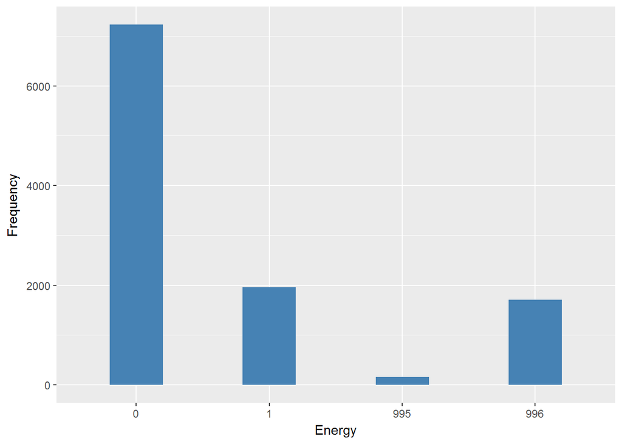

#### 2.1.4.4 Validation

|  | 1->1 | 2,3,4->0 | -9->995 | -1->996 |
| --- | --- | --- | --- | --- |
| BeforeH | 7229 | 1957 | 156 | 1708 |
| AfterH | 7229 | 1957 | 156 | 1708 |

### 2.1.5 Wave 5

#### 2.1.5.1 Study-specific variable description

| **Name** | `scqolo` |
| --- | --- |
| **Label** | `How often feels full of energy these days` |
| **Table name** | `wave_5_elsa_data_v4` |
| **Categories** | `1 = Often; 2 = Sometimes; 3 = Not often; 4 = Never` |
| **Missings** | `-9 = Not answered; -8 = Don't know; -2 = Schedule not applicable; -1 = Item not applicable` |
| **Description** |  |

scqolo

| Sample size | Missing values |
| --- | --- |
| 10274 | 1366 |

Category

|  | 1 | 2 | 3 | 4 |
| --- | --- | --- | --- | --- |
| Frequency | 1934.00 | 4388.00 | 1945.00 | 641.00 |
| Percentage | 18.82 | 42.71 | 18.93 | 6.24 |

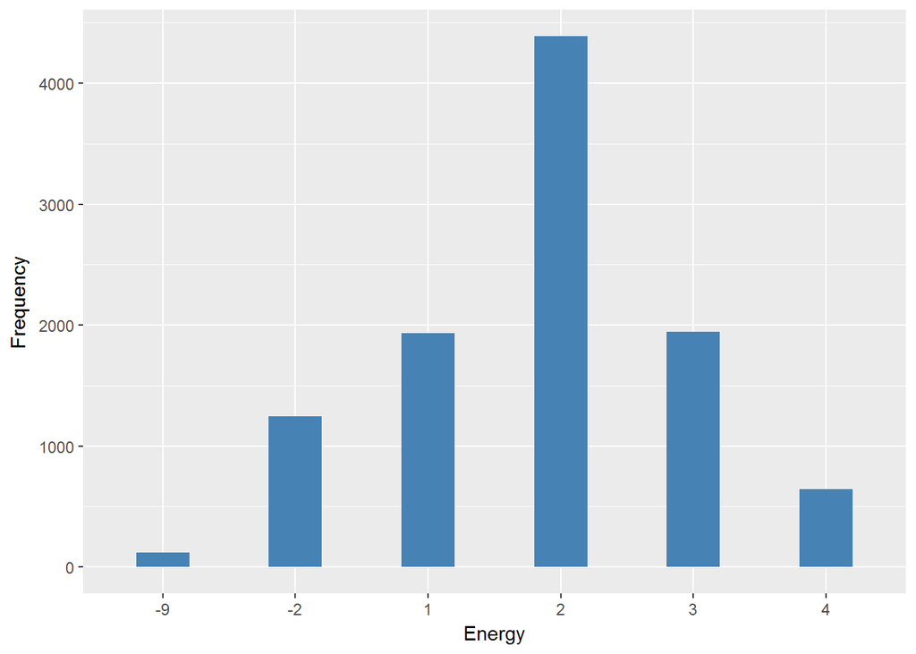

#### 2.1.5.2 Harmonisation algorithm

To compute the harmonize variable from the study-specific variable it has to be recoded as follows:

- `1 into 1`
- `2 into 0`
- `3 into 0`
- `4 into 0`
- `-9 Not answered into 995`
- `-2 Schedule not applicable into 996`
- `-1 Item not applicable into 996`

**R script:**

```r
ELSA_ds_w5 <- tibble(id = ELSA_w5_energy$id)
ELSA_ds_w5$energy <- car::recode(ELSA_w5_energy$scqolo, "1 = '1';2 = '0';3 = '0';4 = '0';-9 = '995';-1 = '996';-2 = '996' ")
ELSA_ds_w5$energy <- labelled(ELSA_ds_w5$energy, labels = c(Yes = 0, No = 1,
    Missing = 999, Do_not_know = 998, Refuse = 997, Not_applicable = 996, Does_not_answer = 995,
    Not_attempt_not_done = 994, Disable_to_measure = 993, Impute = 992, CAPI_interviewer_error = 991))
```

#### 2.1.5.3 Statistical description of the new harmonised variable

energy

| Sample size | Missing values |
| --- | --- |
| 10274 | 1366 |

Category

|  | 0 | 1 |
| --- | --- | --- |
| Frequency | 6974.00 | 1934.00 |
| Percentage | 67.88 | 18.82 |

Type of missing

|  | 991 | 992 | 993 | 994 | 995 | 996 | 997 | 998 | 999 | NA |
| --- | --- | --- | --- | --- | --- | --- | --- | --- | --- | --- |
| Frequency | 0 | 0 | 0 | 0 | 122.00 | 1244.00 | 0 | 0 | 0 | 0 |
| Percentage | 0 | 0 | 0 | 0 | 1.19 | 12.11 | 0 | 0 | 0 | 0 |

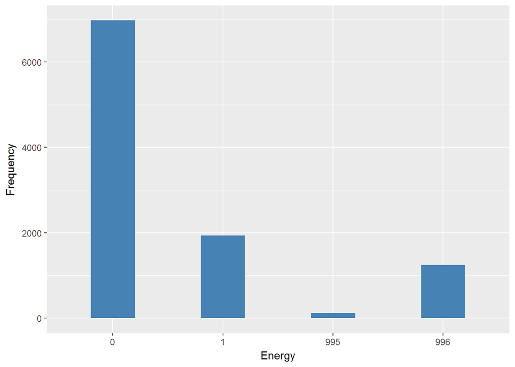

#### 2.1.5.4 Validation

|  | 1->1 | 2,3,4->0 | -9->995 | -2->996 |
| --- | --- | --- | --- | --- |
| BeforeH | 6974 | 1934 | 122 | 1244 |
| AfterH | 6974 | 1934 | 122 | 1244 |

### 2.1.6 Wave 6

#### 2.1.6.1 Study-specific variable description

| **Name** | `scqolo` |
| --- | --- |
| **Label** | `How often feels full of energy these days` |
| **Table name** | `wave_6_elsa_data_v2` |
| **Categories** | `1 = Often; 2 = Sometimes; 3 = Not often; 4 = Never` |
| **Missings** | `-9 = Not answered; -8 = Don't know; -2 = Schedule not applicable; -1 = Item not applicable` |
| **Description** |  |

scqolo

| Sample size | Missing values |
| --- | --- |
| 10601 | 1704 |

Category

|  | 1 | 2 | 3 | 4 |
| --- | --- | --- | --- | --- |
| Frequency | 1820.00 | 4404.00 | 2029.00 | 644.00 |
| Percentage | 17.17 | 41.54 | 19.14 | 6.07 |

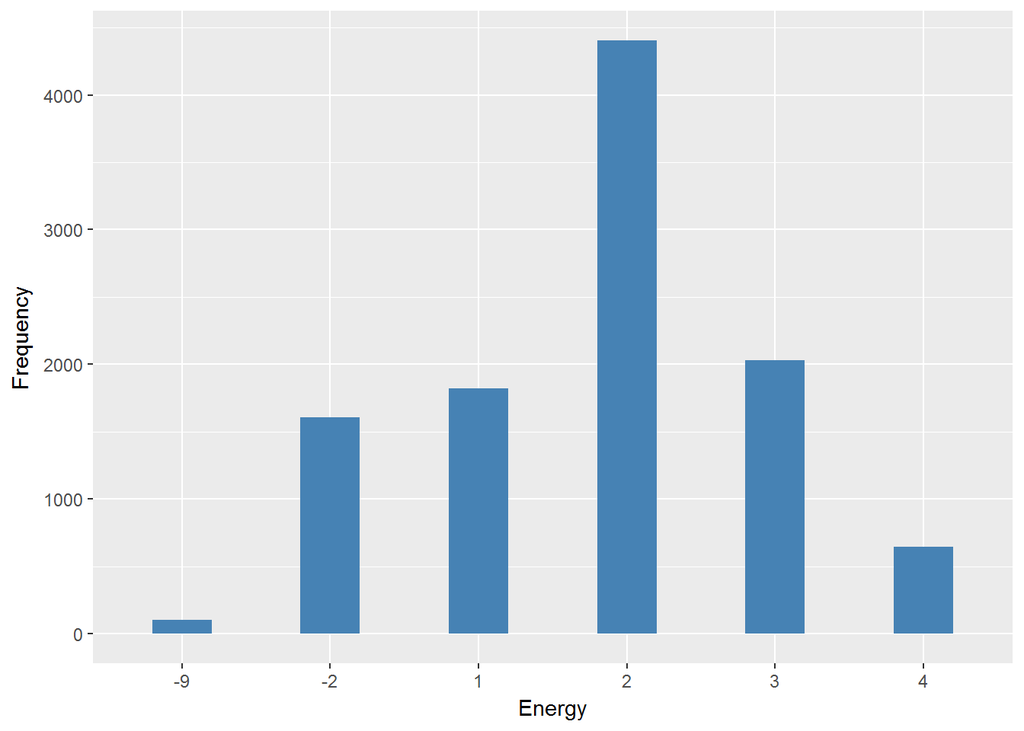

#### 2.1.6.2 Harmonisation algorithm

To compute the harmonize variable from the study-specific variable it has to be recoded as follows:

- `1 into 1`
- `2 into 0`
- `3 into 0`
- `4 into 0`
- `-9 Not answered into 995`
- `-2 Schedule not applicable into 996`
- `-1 Item not applicable into 996`

**R script:**

```r
ELSA_ds_w6 <- tibble(id = ELSA_w6_energy$id)
ELSA_ds_w6$energy <- car::recode(ELSA_w6_energy$scqolo, "1 = '1';2 = '0';3 = '0';4 = '0';-9 = '995';-1 = '996';-2 = '996' ")
ELSA_ds_w6$energy <- labelled(ELSA_ds_w6$energy, labels = c(Yes = 0, No = 1,
    Missing = 999, Do_not_know = 998, Refuse = 997, Not_applicable = 996, Does_not_answer = 995,
    Not_attempt_not_done = 994, Disable_to_measure = 993, Impute = 992, CAPI_interviewer_error = 991))
```

#### 2.1.6.3 Statistical description of the new harmonised variable

energy

| Sample size | Missing values |
| --- | --- |
| 10601 | 1704 |

Category

|  | 0 | 1 |
| --- | --- | --- |
| Frequency | 7077.00 | 1820.00 |
| Percentage | 66.76 | 17.17 |

Type of missing

|  | 991 | 992 | 993 | 994 | 995 | 996 | 997 | 998 | 999 | NA |
| --- | --- | --- | --- | --- | --- | --- | --- | --- | --- | --- |
| Frequency | 0 | 0 | 0 | 0 | 100.00 | 1604.00 | 0 | 0 | 0 | 0 |
| Percentage | 0 | 0 | 0 | 0 | 0.94 | 15.13 | 0 | 0 | 0 | 0 |

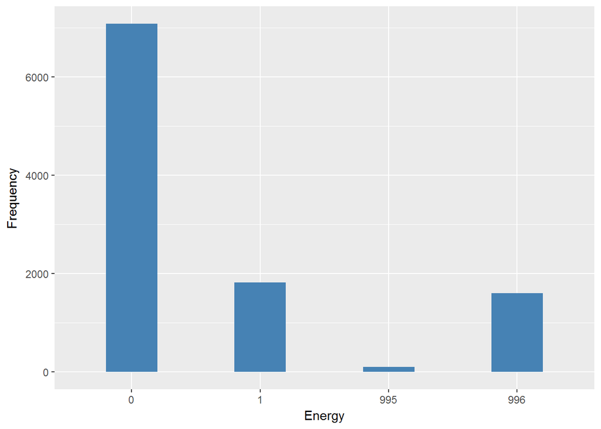

#### 2.1.6.4 Validation

|  | 1->1 | 2,3,4->0 | -9->995 | -2->996 |
| --- | --- | --- | --- | --- |
| BeforeH | 7077 | 1820 | 100 | 1604 |
| AfterH | 7077 | 1820 | 100 | 1604 |

### 2.1.7 Wave 7

#### 2.1.7.1 Study-specific variable description

| **Name** | `scqolo` |
| --- | --- |
| **Label** | `How often feels full of energy these days` |
| **Table name** | `wave_7_elsa_data` |
| **Categories** | `1 = Often; 2 = Sometimes; 3 = Not often; 4 = Never` |
| **Missings** | `-9 = Not answered; -2 = Schedule not applicable` |
| **Description** |  |

scqolo

| Sample size | Missing values |
| --- | --- |
| 9666 | 1595 |

Category

|  | 1 | 2 | 3 | 4 |
| --- | --- | --- | --- | --- |
| Frequency | 1869.00 | 3982.0 | 1697.00 | 523.00 |
| Percentage | 19.34 | 41.2 | 17.56 | 5.41 |

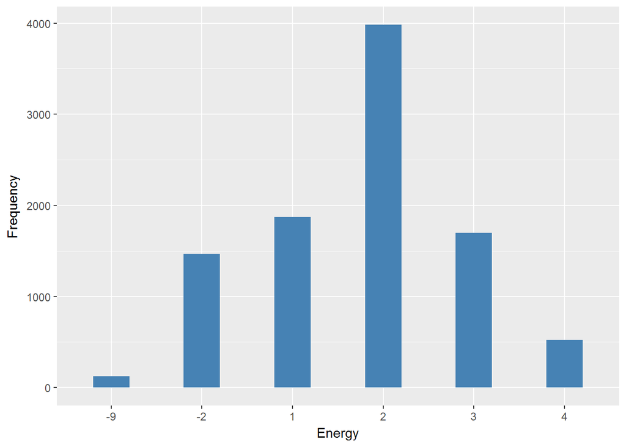

#### 2.1.7.2 Harmonisation algorithm

To compute the harmonize variable from the study-specific variable it has to be recoded as follows:

- `1 into 1`
- `2 into 0`
- `3 into 0`
- `4 into 0`
- `-9 Not answered into 995`
- `-2 Schedule not applicable into 996`

**R script:**

```r
ELSA_ds_w7 <- tibble(id = ELSA_w7_energy$id)
ELSA_ds_w7$energy <- car::recode(ELSA_w7_energy$scqolo, "1 = '1';2 = '0';3 = '0';4 = '0';-9 = '995';-1 = '996';-2 = '996' ")
ELSA_ds_w7$energy <- labelled(ELSA_ds_w7$energy, labels = c(Yes = 0, No = 1,
    Missing = 999, Do_not_know = 998, Refuse = 997, Not_applicable = 996, Does_not_answer = 995,
    Not_attempt_not_done = 994, Disable_to_measure = 993, Impute = 992, CAPI_interviewer_error = 991))
```

#### 2.1.7.3 Statistical description of the new harmonised variable

energy

| Sample size | Missing values |
| --- | --- |
| 9666 | 1595 |

Category

|  | 0 | 1 |
| --- | --- | --- |
| Frequency | 6202.00 | 1869.00 |
| Percentage | 64.16 | 19.34 |

Type of missing

|  | 991 | 992 | 993 | 994 | 995 | 996 | 997 | 998 | 999 | NA |
| --- | --- | --- | --- | --- | --- | --- | --- | --- | --- | --- |
| Frequency | 0 | 0 | 0 | 0 | 126.0 | 1469.0 | 0 | 0 | 0 | 0 |
| Percentage | 0 | 0 | 0 | 0 | 1.3 | 15.2 | 0 | 0 | 0 | 0 |

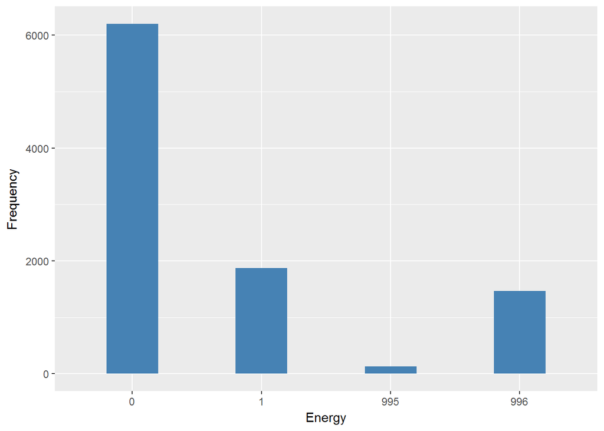

#### 2.1.7.4 Validation

|  | 1->1 | 2,3,4->0 | -9->995 | -2->996 |
| --- | --- | --- | --- | --- |
| BeforeH | 6202 | 1869 | 126 | 1469 |
| AfterH | 6202 | 1869 | 126 | 1469 |

## 2.2 Summary of descriptive statistics of the harmonised variable accross populations and waves

Two tables are generated:

1. Percentages of categories in each harmonised variable.
2. Frequencies and percentages of individuals with different trajectories. To avoid too large table, Only trajectories with percentages larger than 0.3 are shown.

**R script:**

```r
ELSA_ds_w1$energy <- labelled(ELSA_ds_w1$energy, labels = c(Presence = 0, Absence = 1,
    Missing = 999, Do_not_know = 998, Refuse = 997, Not_applicable = 996, Does_not_answer = 995,
    Not_attempt_not_done = 994, Disable_to_measure = 993, Impute = 992, CAPI_interviewer_error = 991))
ELSA_ds_w2$energy <- labelled(ELSA_ds_w2$energy, labels = c(Presence = 0, Absence = 1,
    Missing = 999, Do_not_know = 998, Refuse = 997, Not_applicable = 996, Does_not_answer = 995,
    Not_attempt_not_done = 994, Disable_to_measure = 993, Impute = 992, CAPI_interviewer_error = 991))
ELSA_ds_w3$energy <- labelled(ELSA_ds_w3$energy, labels = c(Presence = 0, Absence = 1,
    Missing = 999, Do_not_know = 998, Refuse = 997, Not_applicable = 996, Does_not_answer = 995,
    Not_attempt_not_done = 994, Disable_to_measure = 993, Impute = 992, CAPI_interviewer_error = 991))
ELSA_ds_w4$energy <- labelled(ELSA_ds_w4$energy, labels = c(Presence = 0, Absence = 1,
    Missing = 999, Do_not_know = 998, Refuse = 997, Not_applicable = 996, Does_not_answer = 995,
    Not_attempt_not_done = 994, Disable_to_measure = 993, Impute = 992, CAPI_interviewer_error = 991))
ELSA_ds_w5$energy <- labelled(ELSA_ds_w5$energy, labels = c(Presence = 0, Absence = 1,
    Missing = 999, Do_not_know = 998, Refuse = 997, Not_applicable = 996, Does_not_answer = 995,
    Not_attempt_not_done = 994, Disable_to_measure = 993, Impute = 992, CAPI_interviewer_error = 991))
ELSA_ds_w6$energy <- labelled(ELSA_ds_w6$energy, labels = c(Presence = 0, Absence = 1,
    Missing = 999, Do_not_know = 998, Refuse = 997, Not_applicable = 996, Does_not_answer = 995,
    Not_attempt_not_done = 994, Disable_to_measure = 993, Impute = 992, CAPI_interviewer_error = 991))
ELSA_ds_w7$energy <- labelled(ELSA_ds_w7$energy, labels = c(Presence = 0, Absence = 1,
    Missing = 999, Do_not_know = 998, Refuse = 997, Not_applicable = 996, Does_not_answer = 995,
    Not_attempt_not_done = 994, Disable_to_measure = 993, Impute = 992, CAPI_interviewer_error = 991))

tt <- frq(ELSA_ds_w1$energy)[[1]][, c(1:2, 4)]
tt[4] <- frq(ELSA_ds_w2$energy)[[1]][, c(4)]
tt[5] <- frq(ELSA_ds_w3$energy)[[1]][, c(4)]
tt[6] <- frq(ELSA_ds_w4$energy)[[1]][, c(4)]
tt[7] <- frq(ELSA_ds_w5$energy)[[1]][, c(4)]
tt[8] <- frq(ELSA_ds_w6$energy)[[1]][, c(4)]
tt[9] <- frq(ELSA_ds_w7$energy)[[1]][, c(4)]
tt[13, ] <- c("n", "sample size", length(ELSA_ds_w1$energy), length(ELSA_ds_w2$energy),
    length(ELSA_ds_w3$energy), length(ELSA_ds_w4$energy), length(ELSA_ds_w5$energy),
    length(ELSA_ds_w6$energy), length(ELSA_ds_w7$energy))
names(tt) <- c("val", "label", "w1", "w2", "w3", "w4", "w5", "w6", "w7")
kable(tt)
```

| val | label | w1 | w2 | w3 | w4 | w5 | w6 | w7 |
| --- | --- | --- | --- | --- | --- | --- | --- | --- |
| 0 | Presence | 66 | 64.36 | 66.7 | 65.42 | 67.88 | 66.76 | 64.16 |
| 1 | Absence | 23.08 | 22.19 | 16.42 | 17.71 | 18.82 | 17.17 | 19.34 |
| 991 | CAPI_interviewer_error | 0 | 0 | 0 | 0 | 0 | 0 | 0 |
| 992 | Impute | 0 | 0 | 0 | 0 | 0 | 0 | 0 |
| 993 | Disable_to_measure | 0 | 0 | 0 | 0 | 0 | 0 | 0 |
| 994 | Not_attempt_not_done | 0 | 0 | 0 | 0 | 0 | 0 | 0 |
| 995 | Does_not_answer | 1.76 | 2.09 | 1.26 | 1.41 | 1.19 | 0.94 | 1.3 |
| 996 | Not_applicable | 9.16 | 11.37 | 15.63 | 15.46 | 12.11 | 15.13 | 15.2 |
| 997 | Refuse | 0 | 0 | 0 | 0 | 0 | 0 | 0 |
| 998 | Do_not_know | 0 | 0 | 0 | 0 | 0 | 0 | 0 |
| 999 | Missing | 0 | 0 | 0 | 0 | 0 | 0 | 0 |
| NA | NA | 0 | 0 | 0 | 0 | 0 | 0 | 0 |
| n | sample size | 12099 | 9432 | 9771 | 11050 | 10274 | 10601 | 9666 |

```r
dbb <- merge(ELSA_m_ds_w1, ELSA_m_ds_w2, by = "id", suffixes = c(".w1", ".w2"),
    all = T)
dbb <- merge(dbb, ELSA_m_ds_w3, by = "id", all = T)
dbb <- merge(dbb, ELSA_m_ds_w4, by = "id", suffixes = c(".w3", ".w4"), all = T)
dbb <- merge(dbb, ELSA_m_ds_w5, by = "id", all = T)
dbb <- merge(dbb, ELSA_m_ds_w6, by = "id", suffixes = c(".w5", ".w6"), all = T)
dbb <- merge(dbb, ELSA_m_ds_w7, by = "id", all = T)
names(dbb) <- c("id", "w1", "w2", "w3", "w4", "w5", "w6", "w7")
v.dbb <- paste(dbb[, 2], dbb[, 3], dbb[, 4], dbb[, 5], dbb[, 6], dbb[, 7], dbb[,
    8], sep = "")
f.dbb <- frq(v.dbb)[[1]][, c(1, 2, 4)]
kable(f.dbb[f.dbb[, 3] >= 0.3, ])
```

|  | val | frq | raw.prc |
| --- | --- | --- | --- |
| 1 | 0000000 | 1357 | 7.34 |
| 3 | 000000NA | 306 | 1.66 |
| 7 | 00000NA0 | 66 | 0.36 |
| 9 | 00000NANA | 274 | 1.48 |
| 22 | 0000NANANA | 275 | 1.49 |
| 42 | 000NA000 | 111 | 0.60 |
| 62 | 000NANANANA | 521 | 2.82 |
| 63 | 0010000 | 56 | 0.30 |
| 107 | 00NA0000 | 85 | 0.46 |
| 150 | 00NANANANANA | 799 | 4.32 |
| 151 | 0100000 | 101 | 0.55 |
| 274 | 01NANANANANA | 80 | 0.43 |
| 275 | 0NA00000 | 63 | 0.34 |
| 308 | 0NA0NANANANA | 128 | 0.69 |
| 374 | 0NANANANANANA | 1700 | 9.19 |
| 375 | 1000000 | 146 | 0.79 |
| 501 | 10NANANANANA | 128 | 0.69 |
| 502 | 1100000 | 80 | 0.43 |
| 586 | 1111111 | 165 | 0.89 |
| 611 | 111NANANANA | 62 | 0.34 |
| 666 | 11NANANANANA | 141 | 0.76 |
| 766 | 1NANANANANANA | 432 | 2.34 |
| 818 | NA0NANANANANA | 119 | 0.64 |
| 871 | NANA00000 | 303 | 1.64 |
| 873 | NANA0000NA | 58 | 0.31 |
| 893 | NANA00NANANA | 64 | 0.35 |
| 933 | NANA0NANANANA | 232 | 1.25 |
| 995 | NANANA0000 | 748 | 4.05 |
| 997 | NANANA000NA | 162 | 0.88 |
| 1003 | NANANA00NANA | 160 | 0.87 |
| 1004 | NANANA0100 | 59 | 0.32 |
| 1021 | NANANA0NANANA | 275 | 1.49 |
| 1035 | NANANA1111 | 125 | 0.68 |
| 1048 | NANANA1NANANA | 66 | 0.36 |
| 1049 | NANANANA000 | 115 | 0.62 |
| 1051 | NANANANA00NA | 67 | 0.36 |
| 1057 | NANANANA0NANA | 93 | 0.50 |
| 1067 | NANANANANA00 | 470 | 2.54 |
| 1068 | NANANANANA01 | 76 | 0.41 |
| 1069 | NANANANANA0NA | 205 | 1.11 |
| 1070 | NANANANANA10 | 66 | 0.36 |
| 1071 | NANANANANA11 | 106 | 0.57 |
| 1072 | NANANANANA1NA | 55 | 0.30 |
| 1073 | NANANANANANA0 | 363 | 1.96 |
| 1074 | NANANANANANA1 | 138 | 0.75 |
| 1075 | NANANANANANANA | 1575 | 8.52 |

ALBERT: I think that recodification of categories is not good enough. Probably, category 2 “sometimes” should be recoded to “1” no (having energy).

# 3 Quality estimation

No comments.